# Contentious Actors, Transnational Information Flows, and Implications for Advocacy in Digital Democracy

## Allison Koh

PhD Researcher

[figure not shown]

Department of Political Economy  
King’s College London  
July 4, 2023

# Current Research

Pro-Government Social Media on the Global Stage

- https://allisonkoh.github.io/files/roasted-rattlesnake.html#/section-3
- https://allisonkoh.github.io/files/roasted-rattlesnake.html#/how-do-globally-accessible-media-attacks-targeting-diaspora-regime-critics-benefit-repressive-governments

## How do authoritarian regimes and their proxies use social media to curtail the global public sphere in their favor?

They integrate foreign platforms into their strategies for intimidating diaspora regime critics.

**At Home** 🏡

**Abroad** 🌍

**Domestic Platforms**

[figure not shown]

[figure not shown]

[figure not shown]

Example of states/proxies controlling platform policies at home (direct control over platform policies; disrupting information flows)

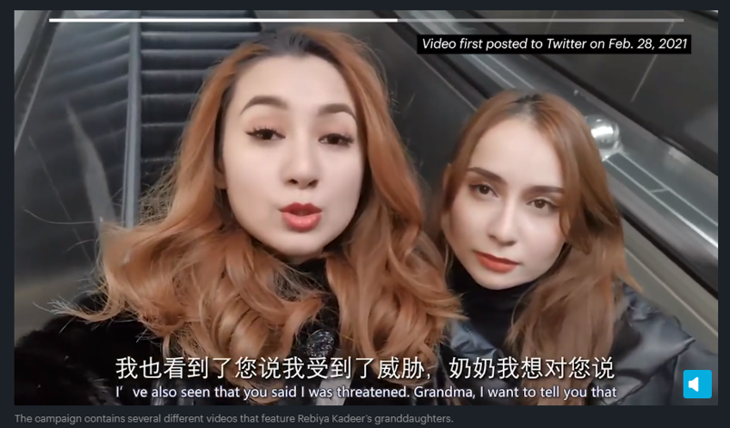

**Foreign Platforms**

[figure not shown]

[figure not shown]

[figure not shown]

Example of state-aligned trolling/harassment; content blocking; platform use restrictions

## How do authoritarian regimes and their proxies use social media to curtail the global public sphere in their favor?

They can leverage gendered [power] dynamics and nationalist themes.

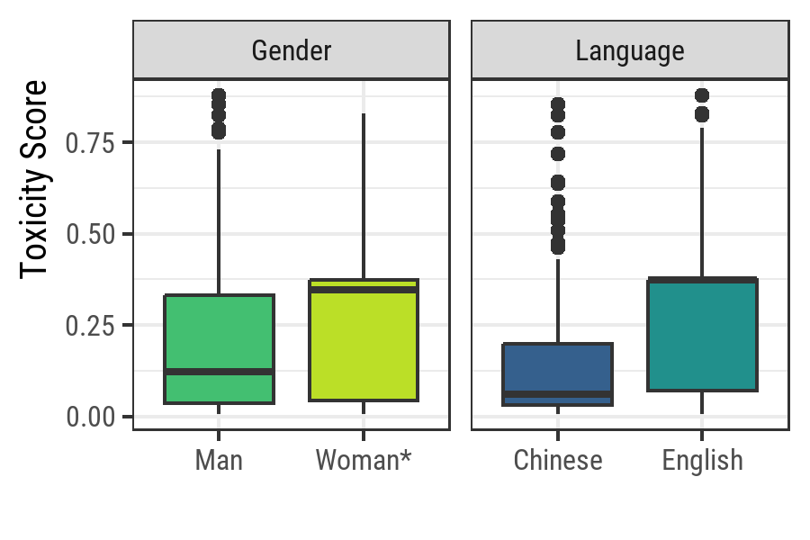

## How do authoritarian regimes and their proxies use social media to curtail the global public sphere in their favor?

## Contributions

- Autocracies and their proxies are capable of manipulating social media to curtail the global public sphere in their favor—*even on platforms where their governments do not have direct provision over content moderation*.

# Potential Contributions to ADVODID

Implications of Anti-LGBTQ+ Rhetoric for Digital Democracy

## Research Questions

## Collaborations at Kings College London

# Thank you!

koh@hertie-school.org

https://allisonkoh.github.io/

@allisonwkoh@mastodon.social🎓

@allisonwkoh@fosstodon.org📊

@allisonkoh_

# Appendix

[figure not shown]

[figure not shown]

http://web.archive.org/web/20230420165609/https://twitter.com/CGTNOfficial

[figure not shown]

http://web.archive.org/web/20230512082121/https://twitter.com/CGTNOfficial

## Measurement

Dependent variables 📈

- H1: Engagement with state actors ⬆️
  - DV1: Retweet volume
  - DV2: Like volume
- H2: Online activity of state actors changes
  - DV3: Tweet volume
  - DV4: Focus ✨
- Modeling strategies TBD contingent on the data available

Measuring focus 👀

- Focus measured as a function of topic diversity: % of unique words used for all topics (Dieng, Ruiz, and Blei 2020)
- ⬆️ focus/⬇️ topic diversity
- Process
  1. Translate tweets to English
  2. Run topic model(s)
  3. Measure topic diversity

# Next Steps

Identifying potential data issues

- Granularity of data ❓
- Some accounts (automatically?) delete tweets that are “too old”

## References

Dieng, Adji B., Francisco J. R. Ruiz, and David M. Blei. 2020. “Topic Modeling in Embedding Spaces.” *Transactions of the Association for Computational Linguistics* 8 (December): 439–53. https://doi.org/10.1162/tacl_a_00325.